# Predicting Survival on the Titanic with Logistic Regression: A Predictive Modeling Case Study

Joshua Xavier

October 26, 2026

# 1 Introduction

The sinking of the *Titanic* in April 1912 is one of the most studied disasters in statistics because the passenger records contain a clear binary outcome, survived or died, along with demographic and ticket information.

I started with a simple logistic regression on fare, and then built a multiple logistic regression with sex, ticket class, age, and family size. That work was about *explaining* survival, so the focus was on the odds ratios and their interpretation.

In this project I use logistic regression as a **predictive algorithm**. That is, given a passenger’s characteristics, can I predict whether that passenger survived, and how well will the model do on passengers it has never seen? To achieve this I use a **training/testing split**,and a **10-fold cross-validation** to choose from different candidate models, and **ROC analysis** (AUC) as a another check on the models. The final model is then evaluated using withheld test data.

# 2 Description of Data and Variables

## 2.1 Data collection

The data set has records for 891 *Titanic* passengers. I use the copy in the seaborn-data repository on GitHub:

https://github.com/mwaskom/seaborn-data/blob/master/titanic.csv

It is a passenger-level list compiled from historical passenger records and is widely distributed online.

## 2.2 Variables

1. **survived**: Binary response, 1 = survived, 0 = died
2. **pclass**: Ticket class (1 = upper, 2 = middle, 3 = lower), categorical
3. **sex**: Sex of the passenger, categorical
4. **embarked**: Port of embarkation (C = Cherbourg, Q = Queenstown, S = Southampton), categorical
5. **age**: Age in years, continuous
6. **fare**: Fare paid, continuous
7. **sibsp**: Number of siblings/spouses aboard, discrete count
8. **parch**: Number of parents/children aboard, discrete count

```r
titanic <- read.csv("https://raw.githubusercontent.com/Joshuaxav/STA321F26/main/titanic.csv",
                    na.strings = c("", "NA"))      # treat blank cells as missing
names(titanic) <- tolower(names(titanic))

vars <- c("survived", "pclass", "sex", "age", "sibsp", "parch", "fare", "embarked")
titanic0 <- titanic[, vars]                        # keep only the variables used in this analysis
n.all <- nrow(titanic0)
miss <- colSums(is.na(titanic0))
head(titanic0)
```

```
  survived pclass    sex age sibsp parch    fare embarked
1        0      3   male  22     1     0  7.2500        S
2        1      1 female  38     1     0 71.2833        C
3        1      3 female  26     0     0  7.9250        S
4        1      1 female  35     1     0 53.1000        S
5        0      3   male  35     0     0  8.0500        S
6        0      3   male  NA     0     0  8.4583        Q
```

Only **age** (177 missing, 19.9%) and **embarked** (2 missing) have missing values. To address this issue, I deleted the records with missing values.

```r
titan <- na.omit(titanic0)
n      <- nrow(titan)
n.surv <- sum(titan$survived == 1)
n.died <- sum(titan$survived == 0)
```

The analytic data set has **712** passengers (179 deleted). Of these, 288 survived (40.4%) and 424 died, so the response is reasonably balanced.

# 3 Research Question

The objective of this analysis is to build a logistic regression model that **predicts whether a passenger survived the sinking** using the passenger’s sex, ticket class, age, family size, fare, and port of embarkation. To do this I will first find which candidate logistic model has the best predictive preformance when judged by cross-validation and ROC analysis. Then I will check how accurately the selected model classifys passengers it has never seen.

# 4 Variable Transformation and Discretization

## 4.1 Variable types

The ticket class `pclass` is stored as the numbers 1, 2, 3, but it is a category and not a quantity, so I convert it, along with `sex` and `embarked`, to factors. The baseline levels are male, 1st class, and Southampton. The response is also a factor. I use the labels “died” and “survived”, with “survived” as the second level, so `glm()` models the probability of surviving.

```r
titan$pclass   <- factor(titan$pclass, levels = c(1, 2, 3), labels = c("1st", "2nd", "3rd"))
titan$sex      <- factor(titan$sex, levels = c("male", "female"))
titan$embarked <- factor(titan$embarked, levels = c("S", "C", "Q"))
titan$survived <- factor(titan$survived, levels = c(0, 1), labels = c("died", "survived"))
```

## 4.2 Variable creation

```r
titan$famsize <- titan$sibsp + titan$parch + 1
```

## 4.3 Exploratory analysis of the numerical variables

I made pairwise scatter plots to look for potential issues with the numerical predictors. Fare is extremely right-skewed, so I use **log(fare + 1)**

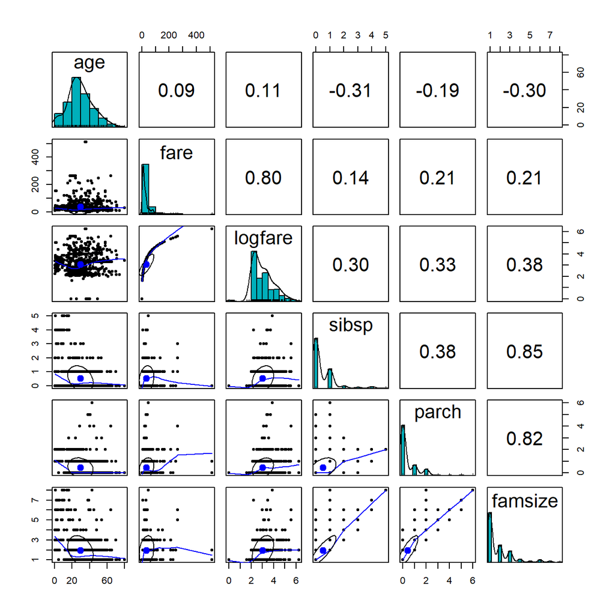

Pairwise scatter plots and correlations of the numerical variables

```r
titan$logfare <- log(titan$fare + 1)
pairs.panels(titan[, c("age","fare", "logfare", "sibsp", "parch", "famsize")],
             method = "pearson",       # correlation method
             hist.col = "#00AFBB",
             density = TRUE,           # show density plots
             ellipses = TRUE)          # show correlation ellipses
```

From the plot I see that fare is extremely skewed (skewness = 4.66), while log(fare + 1) is much more symmetric (skewness = 0.55), so I use the log version.`famsize` is also strongly correlated with `sibsp` and `parch` because it is built from them, which is why I use only `famsize`. Age and family size are moderately negatively correlated (*r* = -0.3), and ticket class and log fare are strongly negatively correlated (*r* = -0.72, since class 1 has the highest fares). I keep both pairs of variables in the candidate models.

## 4.4 Variables I standardize

Since this is a predictive model, I don’t need the coefficients to be on an interpretable scale. The one numerical predictor kept in its numerical form is the log-transformed fare, and I standardized it:

- **sd.logfare** = (log(fare + 1) - mean) / SD

```r
titan$sd.logfare <- (titan$logfare - mean(titan$logfare)) / sd(titan$logfare)
```

## 4.5 Variables I discretize

Age and family size are not expected to have a linear effect on survival since children were given priority for lifeboats, and very large families did poorly. I discretize both. The table shows the survival rate in each group, and none of the groups is too sparse.

```r
titan$grp.age <- cut(titan$age, breaks = c(0, 13, 36, 60, Inf), right = FALSE,
                     labels = c("0-12", "13-35", "36-59", "60+"))
titan$grp.age <- relevel(titan$grp.age, ref = "13-35")      # largest group is the baseline
titan$grp.fam <- cut(titan$famsize, breaks = c(0, 1, 4, Inf), labels = c("alone", "2-4", "5+"))

rate.tab <- function(x) {
  data.frame(Group = names(table(x)),
             n = as.numeric(table(x)),
             Survival.rate = round(as.numeric(tapply(titan$survived == "survived", x, mean)), 3))
}
pander(rate.tab(titan$grp.age), caption = "Age group: sample size and survival rate")
```

Age group: sample size and survival rate

| Group | n | Survival.rate |
| --- | --- | --- |
| 13-35 | 428 | 0.39 |
| 0-12 | 69 | 0.58 |
| 36-59 | 190 | 0.395 |
| 60+ | 25 | 0.24 |

```r
pander(rate.tab(titan$grp.fam), caption = "Family size group: sample size and survival rate")
```

Family size group: sample size and survival rate

| Group | n | Survival.rate |
| --- | --- | --- |
| alone | 402 | 0.318 |
| 2-4 | 259 | 0.579 |
| 5+ | 51 | 0.196 |

- **grp.age**: 0-12, 13-35 (baseline), 36-59, and 60+
- **grp.fam**: alone (size 1), 2-4, and 5 or more

## 4.6 The analytic data set

I drop all of the original variables that were transformed, combined, or discretized, and keep only the response and the predictors that will be used in the models.

```r
sd.titan <- titan[, c("survived", "sex", "pclass", "embarked", "grp.age", "grp.fam", "sd.logfare")]
str(sd.titan)
```

```
'data.frame':   712 obs. of  7 variables:
 $ survived  : Factor w/ 2 levels "died","survived": 1 2 2 2 1 1 1 2 2 2 ...
 $ sex       : Factor w/ 2 levels "male","female": 1 2 2 2 1 1 1 2 2 2 ...
 $ pclass    : Factor w/ 3 levels "1st","2nd","3rd": 3 1 3 1 3 1 3 3 2 3 ...
 $ embarked  : Factor w/ 3 levels "S","C","Q": 1 2 1 1 1 1 1 1 2 1 ...
 $ grp.age   : Factor w/ 4 levels "13-35","0-12",..: 1 3 1 1 1 3 2 1 1 2 ...
 $ grp.fam   : Factor w/ 3 levels "alone","2-4",..: 2 2 1 2 1 1 3 2 2 2 ...
 $ sd.logfare: num  -0.976 1.306 -0.893 1.002 -0.878 ...
```

# 5 Data Split - Training and Testing Data

I **randomly** split the data into two subsets: **80%** of the passengers form the **training data** and the remaining **20%** form the **testing data**. The training data are used to build the candidate models, validate them with cross-validation, and select the final model. The test data are not touched until the very end, and are used only once, to report the actual performance of the final model. A seed is set so the split can be reproduced.

```r
set.seed(321)
train.n  <- round(0.8 * n)
train.id <- sample(1:n, train.n, replace = FALSE)
train <- sd.titan[train.id, ]
test  <- sd.titan[-train.id, ]
split.tab <- data.frame(Data = c("Training", "Testing"),
                        n = c(nrow(train), nrow(test)),
                        Percent.survived = round(100 * c(mean(train$survived == "survived"),
                                                         mean(test$survived == "survived")), 1))
pander(split.tab, caption = "Sample size and percent survived in the training and testing data")
```

Sample size and percent survived in the training and testing data

| Data | n | Percent.survived |
| --- | --- | --- |
| Training | 570 | 38.9 |
| Testing | 142 | 46.5 |

# 6 Candidate Models

I use three kinds of candidate models:

1. **Full model**: all six predictors, `sex + pclass + embarked + grp.age + sd.logfare + grp.fam`.
2. **Reduced model**: only `sex + pclass`. These two were forced in as the essential risk factors (the “women and children first” policy and lifeboat access by class).
3. **Stepwise model**: forward selection by AIC (`stepAIC()`), starting from the reduced model with the full model as the upper limit.

```r
f.full <- survived ~ sex + pclass + embarked + grp.age + sd.logfare + grp.fam
f.red  <- survived ~ sex + pclass
```

The stepwise model has to be re-selected on each set of data it is fit to. Inside the cross-validation below, I repeat the stepwise search within every training fold so that the validation fold never influences the variable selection. I also fit all three models to the entire training set.

```r
m.full <- glm(f.full, family = binomial(link = "logit"), data = train)
m.red  <- glm(f.red,  family = binomial(link = "logit"), data = train)
m.step <- stepAIC(m.red,
                  scope = list(lower = formula(m.red), upper = formula(m.full)),
                  direction = "forward",     # forward selection
                  trace = 0)                 # do not show the details
step.terms <- attr(terms(m.step), "term.labels")
```

On the entire training set, the stepwise search ends with **sex + pclass + grp.age + grp.fam**, so embarked and sd.logfare are not added.

# 7 Final Model Selection

## 7.1 Cross-validation

I use **10-fold cross-validation** on the training data only. The training data is randomly divided into 10 folds of about the same size. Each fold takes a turn as the validation set while the three candidate models are fit to the other nine folds. Each fitted model predicts the validation fold, and the **prediction error (PE)** is the proportion of misclassified passengers. Following the class case study, I use the common cut-off probability of **0.5** for all three candidate models since a passenger is predicted to survive if the predicted probability is greater than 0.5. The average PE over the 10 folds is the score of each candidate.

```r
k <- 10
cutoff <- 0.5
fold <- sample(rep(1:k, length.out = nrow(train)))        # random fold assignment
PE <- matrix(NA, nrow = k, ncol = 3, dimnames = list(NULL, c("Full", "Stepwise", "Reduced")))

for (i in 1:k) {
  valid     <- train[fold == i, ]                           # validation fold
  train.dat <- train[fold != i, ]                           # the other k - 1 folds
  ## candidate models fit to the k - 1 folds
  cand.full <- glm(f.full, family = binomial(link = "logit"), data = train.dat)
  cand.red  <- glm(f.red,  family = binomial(link = "logit"), data = train.dat)
  cand.step <- stepAIC(cand.red,
                       scope = list(lower = formula(cand.red), upper = formula(cand.full)),
                       direction = "forward", trace = 0)
  ## predicted probabilities for the validation fold
  prob <- cbind(predict(cand.full, newdata = valid, type = "response"),
                predict(cand.step, newdata = valid, type = "response"),
                predict(cand.red,  newdata = valid, type = "response"))
  pred.outcome <- ifelse(prob > cutoff, "survived", "died")
  PE[i, ] <- colMeans(pred.outcome != as.character(valid$survived))
}
avg.pe <- colMeans(PE)                                      # average prediction error
se.pe  <- apply(PE, 2, sd) / sqrt(k)                        # standard error of the average
pander(rbind(Avg.PE = avg.pe, SE = se.pe), caption = "Average 10-fold cross-validation prediction error of the candidate models")
```

Average 10-fold cross-validation prediction error of the candidate models

|  | Full | Stepwise | Reduced |
| --- | --- | --- | --- |
| **Avg.PE** | 0.1825 | 0.1842 | 0.214 |
| **SE** | 0.01816 | 0.02208 | 0.01565 |

The full model has the smallest average prediction error (0.1825), and the stepwise model is essentialy tied with it (0.1842). The difference between them is far smaller than the standard error of either average, so cross-validation can’t tell them apart. The reduced model is worse (0.214, more than one standard error above the best), which suggests that age and family size carry predictive information beyond sex and class.

Since the candidates models are statistically tied, I choose the simplest one (the one-standard-error rule). The simplest model whose is the **stepwise model**, so it is the winner of the cross-validation.

Following Step 4 of the cross-validation procedure, I now use the winner fit to the entire training set as the final working model.

```r
final.model <- list(Full = m.full, Stepwise = m.step, Reduced = m.red)[[cv.winner]]
formula(final.model)
```

```
survived ~ sex + pclass + grp.age + grp.fam
```

```r
pander(summary(final.model)$coef, caption = "Coefficients of the final model (fit to the entire training set)")
```

Coefficients of the final model (fit to the entire training set)

|  | Estimate | Std. Error | z value | Pr(>\|z\|) |
| --- | --- | --- | --- | --- |
| **(Intercept)** | 0.129 | 0.2984 | 0.4322 | 0.6656 |
| **sexfemale** | 2.844 | 0.2563 | 11.09 | 1.329e-28 |
| **pclass2nd** | -1.221 | 0.3218 | -3.795 | 0.0001479 |
| **pclass3rd** | -2.258 | 0.324 | -6.972 | 3.134e-12 |
| **grp.age0-12** | 2.071 | 0.4752 | 4.358 | 1.313e-05 |
| **grp.age36-59** | -0.7768 | 0.2854 | -2.721 | 0.006502 |
| **grp.age60+** | -1.37 | 0.6943 | -1.973 | 0.04846 |
| **grp.fam2-4** | -0.3218 | 0.2638 | -1.22 | 0.2225 |
| **grp.fam5+** | -2.665 | 0.5965 | -4.469 | 7.873e-06 |

## 7.2 Final model reporting - performance on the test data

The accuracy reported to a client MUST come from the withheld **test data**, because the validation folds were used to choose the model and therefore give a slightly optimistic picture. The parameters of the final model are not changed in any way after this step.

```r
prob.test <- predict(final.model, newdata = test, type = "response")
pred.test <- factor(ifelse(prob.test > 0.5, "survived", "died"), levels = c("died", "survived"))
cm <- table(Predicted = pred.test, Actual = test$survived)
cm
```

```
          Actual
Predicted  died survived
  died       66       22
  survived   10       44
```

```r
TP <- cm["survived", "survived"]; FP <- cm["survived", "died"]
FN <- cm["died", "survived"];     TN <- cm["died", "died"]
perf <- data.frame(Accuracy = (TP + TN) / sum(cm),
                   Prediction.Error = (FP + FN) / sum(cm),
                   Sensitivity = TP / (TP + FN),
                   Specificity = TN / (TN + FP),
                   False.Negative.Rate = FN / (TP + FN),
                   False.Positive.Rate = FP / (FP + TN))
pander(round(perf, 4), caption = "Performance of the final model on the test data (cut-off = 0.5)")
```

Performance of the final model on the test data (cut-off = 0.5) (continued below)

| Accuracy | Prediction.Error | Sensitivity | Specificity | False.Negative.Rate |
| --- | --- | --- | --- | --- |
| 0.7746 | 0.2254 | 0.6667 | 0.8684 | 0.3333 |

| False.Positive.Rate |
| --- |
| 0.1316 |

```r
roc.test.obj <- roc(test$survived, prob.test, levels = c("died", "survived"), direction = "<", quiet = TRUE)
auc.test <- as.numeric(auc(roc.test.obj))
base.acc <- max(table(test$survived)) / nrow(test)         # accuracy of always predicting the majority class
```

On the test data, the final model has an accuracy of **77.5%** (prediction error 22.5%), with a sensitivity of 66.7% and a specificity of 86.8%. The test-data AUC is 0.877. For comparison, simply predicting the majority class (“died”) for everyone would be right 53.5% of the time, so the model is a real improvement over the baseline.

The test accuracy is a bit lower than the accuracy implied by the cross-validation (1 - 0.184 = 81.6%). That’s not unusual. The test set has only 142 passengers, so its accuracy has a standard error of roughly 3.5 percentage points. The model is noticeably better at identifying who died (specificity) than who survived (sensitivity), which is typical when the cut-off is 0.5 and “died” is the larger group.

## 7.3 ROC analysis - global performance

The accuracy and PE above depend on the cut-off probability, so they are *local* performance measures. The ROC curve plots the sensitivity (TPR) against 1 - specificity (FPR) over all possible cut-offs, and the area under the curve (AUC) is a **global** measure of how well the model ranks survivors above non-survivors. Since the ROC is used for model selection, I construct the ROC curves from the **training data** for the three candidate models.

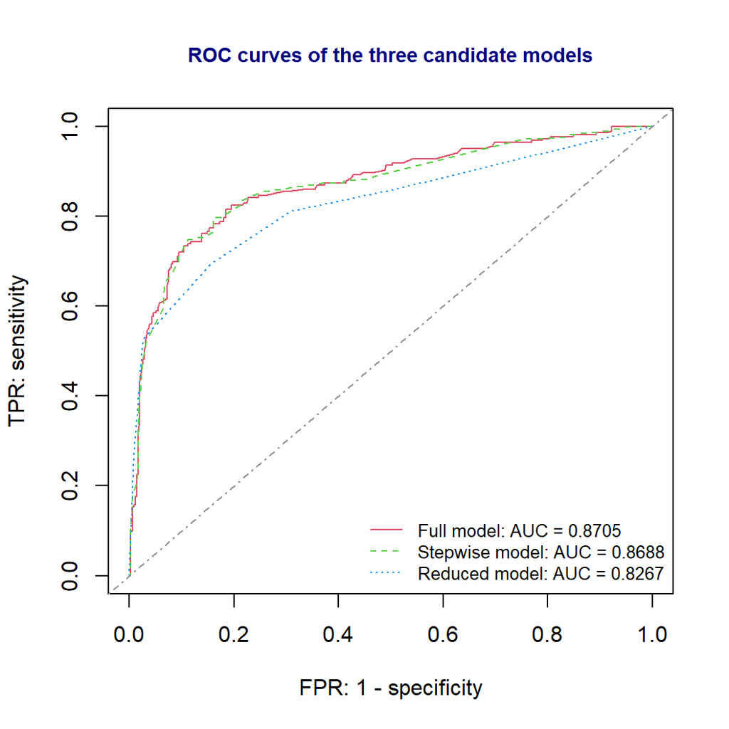

ROC curves of the three candidate models (training data)

```r
mk.roc <- function(m) roc(train$survived, as.vector(predict(m, newdata = train, type = "response")),
                          levels = c("died", "survived"), direction = "<", quiet = TRUE)
ROC.full <- mk.roc(m.full)
ROC.step <- mk.roc(m.step)
ROC.red  <- mk.roc(m.red)
AUC.full <- round(as.numeric(auc(ROC.full)), 4)
AUC.step <- round(as.numeric(auc(ROC.step)), 4)
AUC.red  <- round(as.numeric(auc(ROC.red)), 4)

plot(1 - ROC.full$specificities, ROC.full$sensitivities, type = "l", col = 2, lty = 1,
     xlim = c(0, 1), ylim = c(0, 1),
     xlab = "FPR: 1 - specificity", ylab = "TPR: sensitivity",
     main = "ROC curves of the three candidate models", cex.main = 0.9, col.main = "navy")
lines(1 - ROC.step$specificities, ROC.step$sensitivities, col = 3, lty = 2)
lines(1 - ROC.red$specificities,  ROC.red$sensitivities,  col = 4, lty = 3)
abline(0, 1, col = "grey60", lty = 4)                       # chance line
legend("bottomright", c(paste("Full model: AUC =", AUC.full),
                        paste("Stepwise model: AUC =", AUC.step),
                        paste("Reduced model: AUC =", AUC.red)),
       col = 2:4, lty = 1:3, cex = 0.8, bty = "n")
```

The full model and the stepwise model have almost the same ROC curve and AUC (0.8705 and 0.8688), and both are better than the reduced model (0.8267). Since the stepwise model is simpler than the full model, the ROC analysis also points to the **stepwise model**, the same conclusion as the cross-validation. (These ROC curves and AUCs are computed on the data the models were fit to, so they are somewhat optimistic in absolute terms, but they are used here only to *compare* the candidates against each other.)

# 8 Summary and Conclusion

This report used logistic regression to predict survival on the *Titanic*. After removing records with a missing age or port, I log-transformed and standardized fare, discretized age and family size, and randomly split the 712 complete passengers into 570 for training and 142 for testing. Three candidate models (full, reduced, and stepwise) were compared using 10-fold cross-validation on the training data and with ROC curves and AUC.

- **Cross-validation:** the full and stepwise models had practically the same average prediction error (0.182 and 0.184), and both beat the reduced model (0.214).
- **ROC analysis:** the AUCs of the full and stepwise models were nearly equal (0.8705 and 0.8688), and both were higher than the reduced model’s (0.8267).
- **Final model:** both methods agreed, so the final model is the simpler **stepwise model**, survived ~ sex + pclass + grp.age + grp.fam. Port of embarkation and fare don’t improve prediction once sex, class, age group, and family size are in the model.
- **Actual performance:** on the 142 withheld test passengers, the final model has an accuracy of 77.5% (compared with 53.5% for always predicting “died”), a sensitivity of 66.7%, a specificity of 86.8%, and an AUC of 0.877.